```python
import pandas as pd
import numpy as np
import warnings
from surprise import SVD, Dataset, accuracy, Reader, KNNBasic, KNNWithMeans
from surprise.model_selection import train_test_split
import time
warnings.filterwarnings("ignore")
```

# Project 4: Movie Recommendation

sh53, SICHENG HE

# 1 Load data

```python
myurl = "https://liangfgithub.github.io/MovieData/"
ratings = pd.read_csv(myurl + 'ratings.dat?raw=true', header=None, sep=':').dropna(axis=1)
# ratings.dropna(axis=1, inplace=True)
ratings.columns = ['UserID', 'MovieID', 'Rating', 'Timestamp']

ratings.drop(['Timestamp'], axis=1, inplace=True)
movies = pd.read_csv(myurl + 'movies.dat?raw=true', header=None, sep='::', encoding='latin1')
movies.columns = ['MovieID', 'Title', 'Genres']

movieid_to_name = {}
for key, value in zip(movies['MovieID'], movies['Title']):
    movieid_to_name[key] = value
```

# 2 System I: recommendation based on genres

First I compute the average rating and the number of ratings of each movie.

```python
movies['Genres'] = movies['Genres'].map(lambda s: s.split('|'))
genre_list = ["Action", "Adventure", "Animation",
               "Children's", "Comedy", "Crime",
               "Documentary", "Drama", "Fantasy",
               "Film-Noir", "Horror", "Musical",
               "Mystery", "Romance", "Sci-Fi",
               "Thriller", "War", "Western"]

for g in  genre_list:
    movies[g] = movies['Genres'].map(lambda x: 1 if g in x else 0)
movie_pop = ratings.groupby(['MovieID'])['Rating'].agg(['mean', 'count']).reset_index()
```

```python
movie_pop.head(5)
```

|  | MovieID | mean | count |
| --- | --- | --- | --- |
| 0 | 1 | 4.146846 | 2077 |
| 1 | 2 | 3.201141 | 701 |
| 2 | 3 | 3.016736 | 478 |
| 3 | 4 | 2.729412 | 170 |
| 4 | 5 | 3.006757 | 296 |

## 2.1 Recommend top 10 most popular movies

The popularity of a movie is measured by the number of rating it received. For each genre, I sort movies in this genre by the number of ratings. Then top 10 movies are saved to be the recommendation for such genre.

```python
genre_popular_10 = pd.DataFrame()
for genre in genre_list:
    movie_spe_genre = movies.loc[movies[genre] == 1, ['MovieID', 'Title']]
    movie_spe_genre = pd.merge(movie_spe_genre, movie_pop, on='MovieID')
    most_popular_10 = movie_spe_genre.sort_values(['count'], ascending=False)[:10]['MovieID'].values.tolist()
    genre_popular_10[genre] = most_popular_10

genre_popular_10 = genre_popular_10.applymap(lambda x : movieid_to_name[x])
```

For example, the top 10 most popular movies for genre 'Action' and 'Adventure':

```python
genre_popular_10[['Action', 'Adventure']]
```

|  | Action | Adventure |
| --- | --- | --- |
| 0 | Star Wars: Episode IV - A New Hope (1977) | Star Wars: Episode IV - A New Hope (1977) |
| 1 | Star Wars: Episode V - The Empire Strikes Back... | Star Wars: Episode V - The Empire Strikes Back... |
| 2 | Star Wars: Episode VI - Return of the Jedi (1983) | Star Wars: Episode VI - Return of the Jedi (1983) |
| 3 | Jurassic Park (1993) | Jurassic Park (1993) |
| 4 | Saving Private Ryan (1998) | Men in Black (1997) |
| 5 | Terminator 2: Judgment Day (1991) | Raiders of the Lost Ark (1981) |
| 6 | Matrix, The (1999) | Princess Bride, The (1987) |
| 7 | Men in Black (1997) | Star Wars: Episode I - The Phantom Menace (1999) |
| 8 | Raiders of the Lost Ark (1981) | Total Recall (1990) |
| 9 | Braveheart (1995) | Who Framed Roger Rabbit? (1988) |

## 2.2 Recommend top 10 highly rated movies

For each genre, first I filter out movies with at least ten ratings. Then I sort these movies by their average ratings. And top 10 movies are saved to be the recommendation for such genre.

```python
geren_highrate_10 = pd.DataFrame()
for genre in genre_list:
    movie_spe_genre = movies.loc[movies[genre] == 1, ['MovieID', 'Title']]
    movie_spe_genre = pd.merge(movie_spe_genre, movie_pop, on='MovieID')
    high_rated_10 = movie_spe_genre[movie_spe_genre['count'] >= 10]
    high_rated_10 = high_rated_10.sort_values(['mean'], ascending=False)[:10]['MovieID'].values.tolist()
    geren_highrate_10[genre] = high_rated_10

geren_highrate_10 = geren_highrate_10.applymap(lambda x : movieid_to_name[x])
```

For example, the top 10 highly rated movies for genre 'Action' and 'Adventure':

```python
geren_highrate_10[['Action', 'Adventure']]
```

|  | Action | Adventure |
| --- | --- | --- |
| 0 | Sanjuro (1962) | Sanjuro (1962) |
| 1 | Seven Samurai (The Magnificent Seven) (Shichin... | Raiders of the Lost Ark (1981) |
| 2 | Godfather, The (1972) | Star Wars: Episode IV - A New Hope (1977) |
| 3 | Raiders of the Lost Ark (1981) | Lawrence of Arabia (1962) |
| 4 | Star Wars: Episode IV - A New Hope (1977) | Great Escape, The (1963) |
| 5 | Godfather: Part II, The (1974) | Dersu Uzala (1974) |
| 6 | Saving Private Ryan (1998) | Princess Bride, The (1987) |
| 7 | Matrix, The (1999) | Star Wars: Episode V - The Empire Strikes Back... |
| 8 | Princess Bride, The (1987) | Treasure of the Sierra Madre, The (1948) |
| 9 | Boat, The (Das Boot) (1981) | African Queen, The (1951) |

# 3 System II: collaborative recommendation system

## 3.1 ten iterations

In each iteration, 80% of the data is randomly chosed to be the training data

```python
reader = Reader(rating_scale=(1, 5))
data = Dataset.load_from_df(ratings[['UserID', 'MovieID', 'Rating']], reader)

sim_options = {'name': 'cosine',
               'user_based': False}

# ten iterations
error_1 = []
error_2 = []
T1 = []
T2 = []
for i in range(10):
    print(i, end=' ')
    # 1
    trainset, testset = train_test_split(data, test_size=0.2, random_state=100 + i)
    st = time.time()
    model1 = KNNWithMeans(k=20, min_k=1, sim_options=sim_options, verbose=False)
    model1.fit(trainset)
    prediction1 = model1.test(testset)
    rmse1 = accuracy.rmse(prediction1, verbose=False)
    t1 = time.time() - st
    print(t1, end=', ')
    # 2
    st = time.time()
    model2 = SVD(n_factors=20, n_epochs=50, random_state=100 + i)
    model2.fit(trainset)
    prediction2 = model2.test(testset)
    rmse2 = accuracy.rmse(prediction2, verbose=False)
    t2 = time.time() - st
    print(t2)
    error_1.append(np.round(rmse1, 4))
    error_2.append(np.round(rmse2, 4))
    T1.append(int(t1))
    T2.append(int(t2))

perf = pd.DataFrame({'splits': range(1, 11),
                    'IBCF_RMSE': error_1 ,
                    'SVD_RMSE': error_2})
```

## 3.2 Item based collaborative filtering

### 3.2.1 Introduction

The item-based collaborative filtering consider similarity between items. Given a similarity measure between items , I use cosine similarity here, item-based approaches predict the rating of a given user on a given item using the ratings of the user on the items considered as similar to the target item. A weighted sum is used to predict the rating of active user a on item i.

- I choose to take into account the mean ratings of each movie.
- For each item, its K nearest neighbors are selected ot give the prediction. Here I set K = 20
- I use cosine similarity.
- If all 20 neighbors are not rated, then the prediction will be the overall average rating of that item.

The predict rating of user u on movie i is set as:

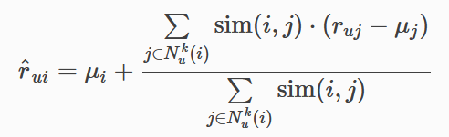

- $\mu_i$ is the mean ratings of movie i
- $N_u^k(i)$ is the set of K nearest neighbors of movie i

The cosine similarity, only common users are taken into account

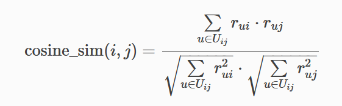

### 3.2.2 RMSE of IBCF over ten iterations

```python
perf[['splits', 'IBCF_RMSE']]
```

|  | splits | IBCF_RMSE |
| --- | --- | --- |
| 0 | 1 | 0.9005 |
| 1 | 2 | 0.9043 |
| 2 | 3 | 0.9009 |
| 3 | 4 | 0.9031 |
| 4 | 5 | 0.9014 |
| 5 | 6 | 0.9028 |
| 6 | 7 | 0.9023 |
| 7 | 8 | 0.9026 |
| 8 | 9 | 0.9019 |
| 9 | 10 | 0.9009 |

## 3.3 SVD based collaborative filtering

### 3.3.1 Introduction

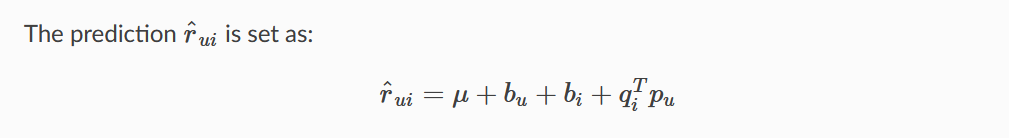

- $q_i, p_u$ are two k dimension latent vectors. Here I set k = 20

To train the mdeol, we minimize the following regularized squared error:

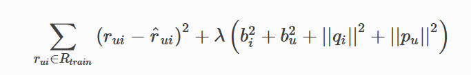

The minimization is performed by stochastic gradient descent

### 3.3.2 RMSE of SVD over ten iterations

```python
perf[['splits', 'SVD_RMSE']]
```

|  | splits | SVD_RMSE |
| --- | --- | --- |
| 0 | 1 | 0.8710 |
| 1 | 2 | 0.8718 |
| 2 | 3 | 0.8703 |
| 3 | 4 | 0.8699 |
| 4 | 5 | 0.8693 |
| 5 | 6 | 0.8714 |
| 6 | 7 | 0.8681 |
| 7 | 8 | 0.8708 |
| 8 | 9 | 0.8701 |
| 9 | 10 | 0.8706 |

# 4 My web app

I'm using Python and Dash to build my recommendation app,

- System I is based on top 10 most popular movies recommendation
- System II is based on IBCF. Movies with top 10 predicted ratings will be recommended.

Link to my dash app,

- http://139.196.50.153/
- If the link above does not work, please try: http://sichenghe.pythonanywhere.com/
- If both of them are not working, please contact me. Maybe I have to reload my app on the server.

Link to the source code of my app

- https://github.com/sxy22/Project_STAT542/blob/master/Project4/app.py

sh53, 655723276, Sicheng He